# Exploring Pediatric Appendicitis

Muhammad Alakhdar

2025-02-13

# Introdution

In 2015, approximately 11.6 million cases of appendicitis were reported, resulting in approximately 50,100 deaths worldwide, deaths could be attributed to many reasons, such as lack of access to medicine, quality of care, and medical diagnostic error.

Helping healthcare professionals make more informed decisions is one way to reduce diagnostic errors.

There are many criteria to do this, such as history taking, physical examination, risk scores (e.g., Alvarado score), and imaging techniques such as ultrasound and CT.

The accuracy of the diagnosis could be improved, for example, by using machine learning. [A recent study built a model to predict appendicitis in pediatrics using an interpretable unsupervised machine learning method](https://doi.org/10.1016/j.media.2023.103042).

[Since a lot of models have been built using just history and physical examinin as predictors, we would use the same dataset to explore the disease for a bit then build models that focus on ultrasonography as a way to diagnose appendicitis.](https://doi.org/10.5281/zenodo.7711412)

# Methodology

[The dataset was acquired in a retrospective study from a cohort of pediatric patients admitted with abdominal pain to Children’s Hospital St. Hedwig in Regensburg, Germany.](https://doi.org/10.5281/zenodo.7711412)

- Taking a look at the dataset

[output not shown]

First Ten Rows of the Pediatric Patients Dataset

| Sex | US_Performed | Severity | Management | Diagnosis |
| --- | --- | --- | --- | --- |
| male | yes | complicated | primary surgical | appendicitis |
| male | yes | uncomplicated | conservative | no appendicitis |
| female | yes | uncomplicated | conservative | no appendicitis |
| male | yes | uncomplicated | secondary surgical | appendicitis |
| male | yes | complicated | primary surgical | appendicitis |
| male | yes | uncomplicated | conservative | no appendicitis |
| male | yes | uncomplicated | primary surgical | appendicitis |
| male | yes | uncomplicated | conservative | appendicitis |
| male | yes | uncomplicated | primary surgical | appendicitis |
| female | yes | uncomplicated | primary surgical | appendicitis |

```
## Number of missing values is 14008
```

## Some Plots

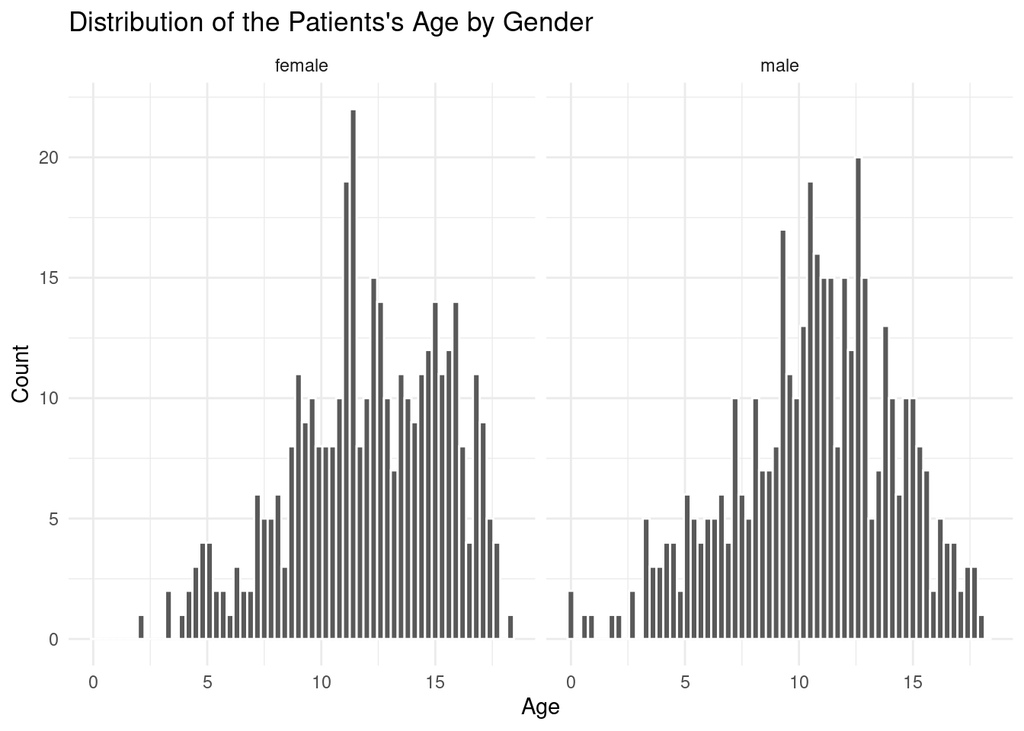

Distribution of the Patients’s Age by Gender

The Mean Age of Patients By Gender

| Sex | Mean |
| --- | --- |
| female | 12.06 |
| male | 10.68 |

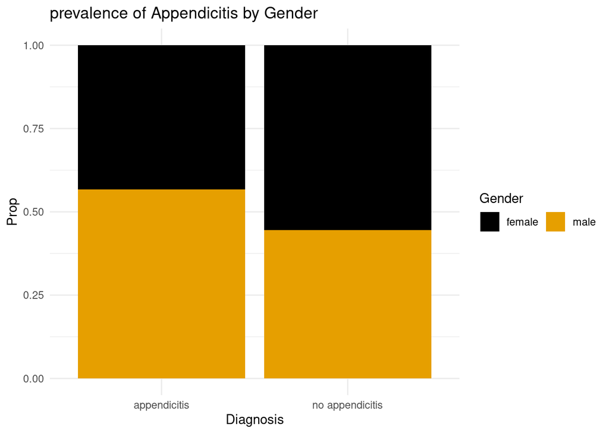

Prevalence of Appendicitis by Gender

Prevalence of Appendicitis by Gender

| Sex | Diagnosis | n | p |
| --- | --- | --- | --- |
| female | appendicitis | 200 | 0.53 |
| female | no appendicitis | 176 | 0.47 |
| male | appendicitis | 262 | 0.65 |
| male | no appendicitis | 141 | 0.35 |

- Figure 2 shows that the prevalence in appendicitis is more males than females, which is consistent with existing findings, but it is not that substantial.

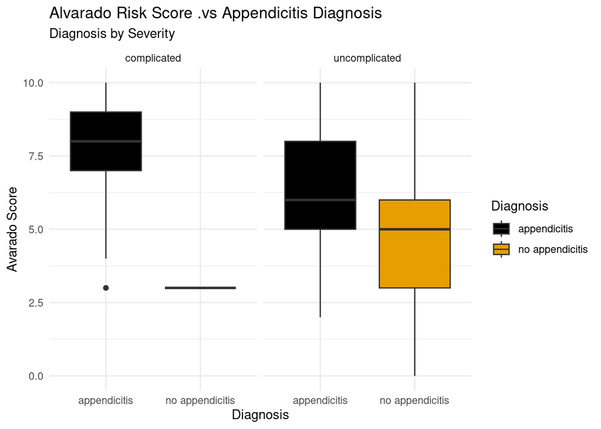

Alvarado Risk Score .vs Appendicitis Diagnosis

Alvarado Risk Score .vs Appendicitis Diagnosis

| Diagnosis | mean | median |
| --- | --- | --- |
| appendicitis | 6.67 | 7 |
| no appendicitis | 4.83 | 5 |

- Alvarado score is a system that have been developed to identify people who are likely to have appendicitis, as a score below 5 suggests against a diagnosis of appendicitis, while a score of 7 or more is predictive of acute appendicitis, but it is performance varies. Here, the severity of the diagnosis was added to see if the score also differed.

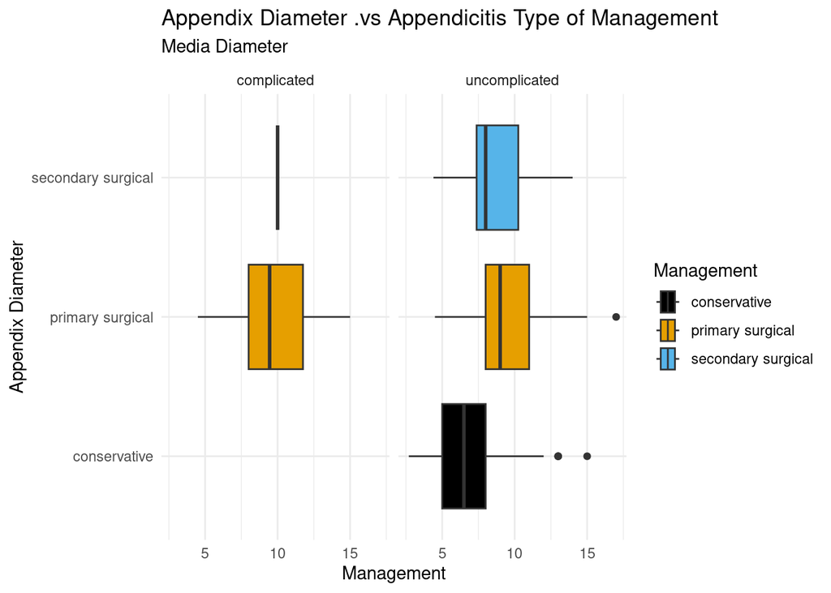

Appendix Diameter .vs Appendicitis Type of Management

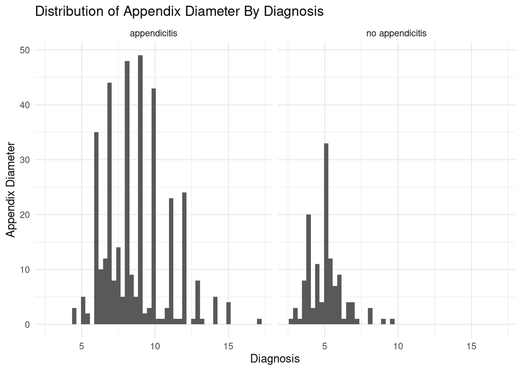

| Diagnosis | mean | median |
| --- | --- | --- |
| appendicitis | 8.70 | 8.2 |
| no appendicitis | 5.04 | 5.0 |

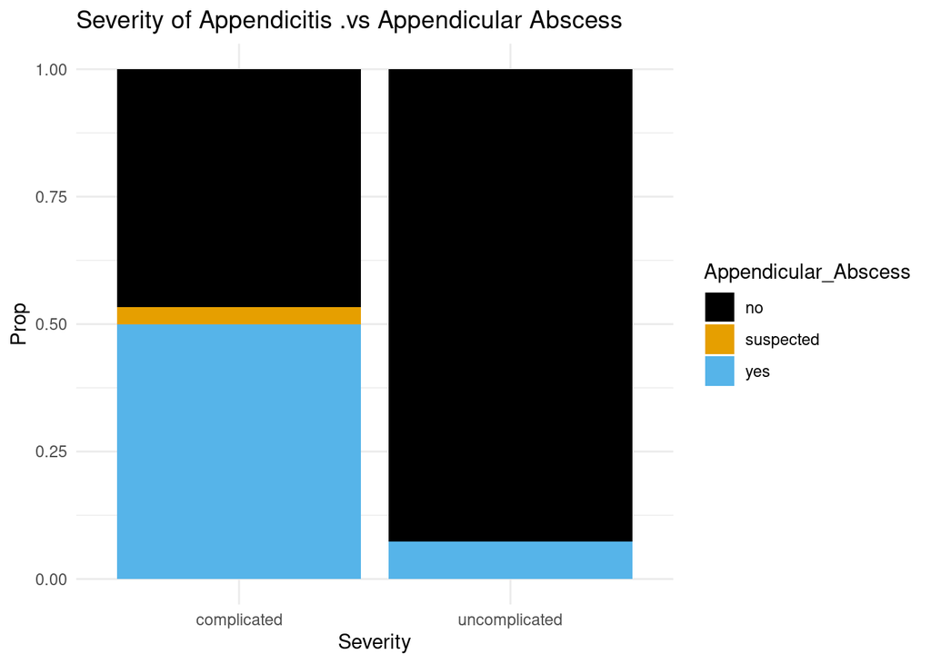

- Severity of Appendicitis .vs Appendicular Abscess

## Statistical Analysis

### Hypothesis testing

- Since the use of ultrasound is less expensive and less harmful than CT, it streamlines the diagnostic process.

Here we will test if the addition of **appendiceal diameter** will have a discernible difference on the outcome of the diagnosis, the method we will use is hypothesis testing with **randomization**.

The two populations of interest in this study are pediatric patients who do or do not have appendicitis.

*Let* $p$ *= the true mean of appendix diameter in pediatric patients.

- So our hypotheses are

$H_0: p_{Appendicitis} = p_{no~Appendicitis}$

$H_A: p_{Appendicitis} \ne p_{no~Appendicitis}$

- With a p-value of 0, which is smaller than the discernability level of 0.05, we reject the null hypothesis. The data provide convincing evidence that there is a difference between the mean appendix diameters of pediatric patients with and without appendicitis.

95% confidence interval for the difference in mean between patients diagnosed with appendicitis or no appendicitis.

| lower_ci | upper_ci |
| --- | --- |
| 3.37 | 3.94 |

- *We are 95% confident that the mean diameter of the appendix in pediatric patients with “appendicitis” is 3.37 to 3.94 greater than in pediatric patients without appendicitis..*

### Modeling

- To help the health workers make more informed decisions (i.e, Accurately diagnosing the appendicitis) we would use machine learning.

We will build Supervised explainable models like logistic regression then test and validate the model.

So we will use **cross validation** as way to build the model then we would use **ROC** to check the models precision and accuracy.

A Model to Diagnose Appendicitis With Avarado Score

| pred_class | pred_appendicitis | pred_no_appendicitis | alvarado_score |
| --- | --- | --- | --- |
| appendicitis | 0.78 | 0.22 | 6 |
| appendicitis | 0.95 | 0.05 | 9 |
| appendicitis | 0.68 | 0.32 | 5 |
| appendicitis | 0.86 | 0.14 | 7 |
| appendicitis | 0.56 | 0.44 | 4 |
| appendicitis | 0.56 | 0.44 | 4 |
| appendicitis | 0.78 | 0.22 | 6 |
| no appendicitis | 0.30 | 0.70 | 2 |
| appendicitis | 0.86 | 0.14 | 7 |
| appendicitis | 0.86 | 0.14 | 7 |

Precision and Accuracy of Model to Diagnose Appendicitis With Avarado Score

| .pred_class | Diagnosis | n | p | decision |
| --- | --- | --- | --- | --- |
| appendicitis | appendicitis | 67 | 0.96 | True positive |
| no appendicitis | appendicitis | 3 | 0.04 | False negative |
| appendicitis | no appendicitis | 14 | 0.61 | False positive |
| no appendicitis | no appendicitis | 9 | 0.39 | True negative |

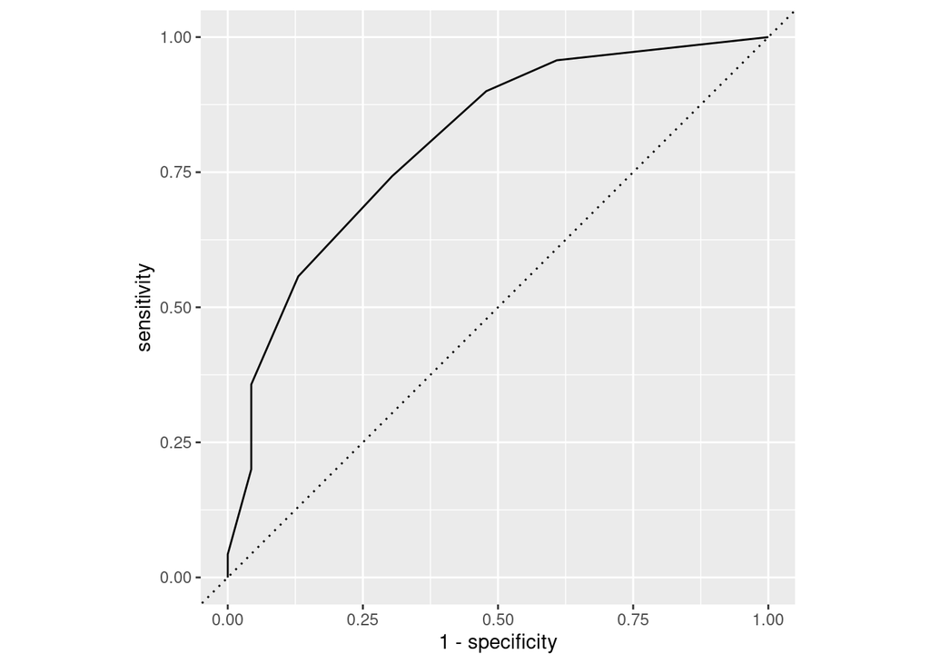

A Model to Diagnose Appendicitis With Avarado Score, Appendix_Diameter, Weight and BMI

| pred_class | pred_appendicitis | pred_no_appendicitis |
| --- | --- | --- |
| no appendicitis | 0.01 | 0.99 |
| no appendicitis | 0.10 | 0.90 |
| no appendicitis | 0.29 | 0.71 |
| appendicitis | 0.80 | 0.20 |
| appendicitis | 0.96 | 0.04 |
| no appendicitis | 0.46 | 0.54 |
| appendicitis | 1.00 | 0.00 |
| no appendicitis | 0.03 | 0.97 |
| appendicitis | 0.85 | 0.15 |
| appendicitis | 1.00 | 0.00 |

Precision and Accuracy of Model to Diagnose Appendicitis With Avarado Score, Appendix_Diameter, Weight and BMI

| .pred_class | Diagnosis | n | p | decision |
| --- | --- | --- | --- | --- |
| appendicitis | appendicitis | 67 | 0.96 | True positive |
| no appendicitis | appendicitis | 3 | 0.04 | False negative |
| no appendicitis | no appendicitis | 23 | 1.00 | True negative |

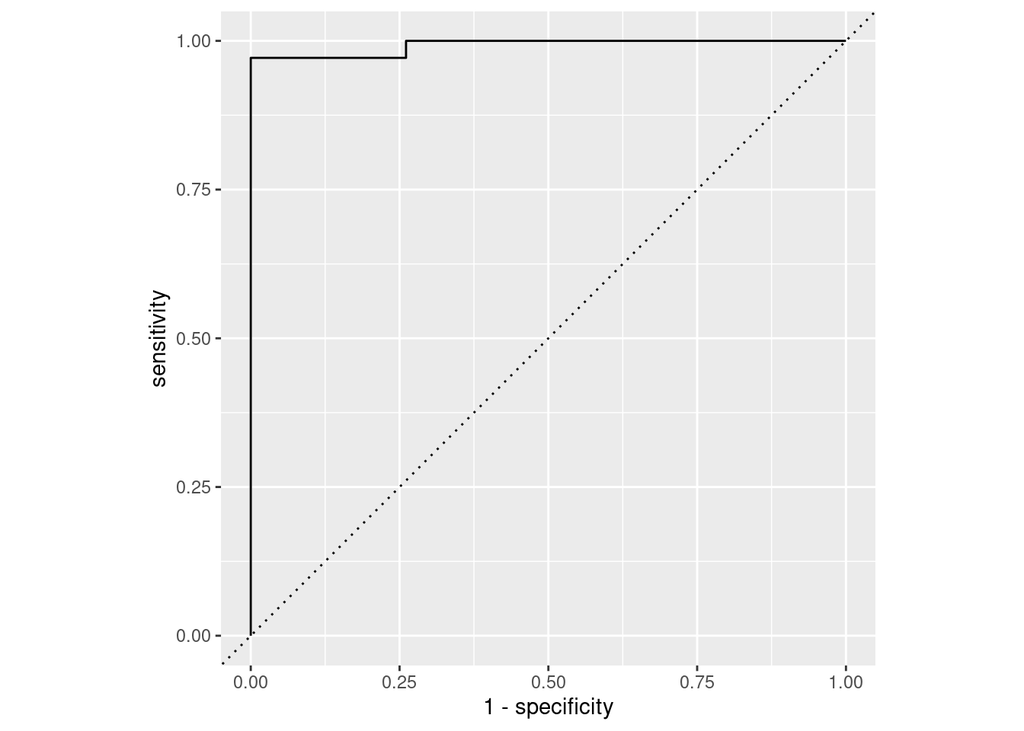

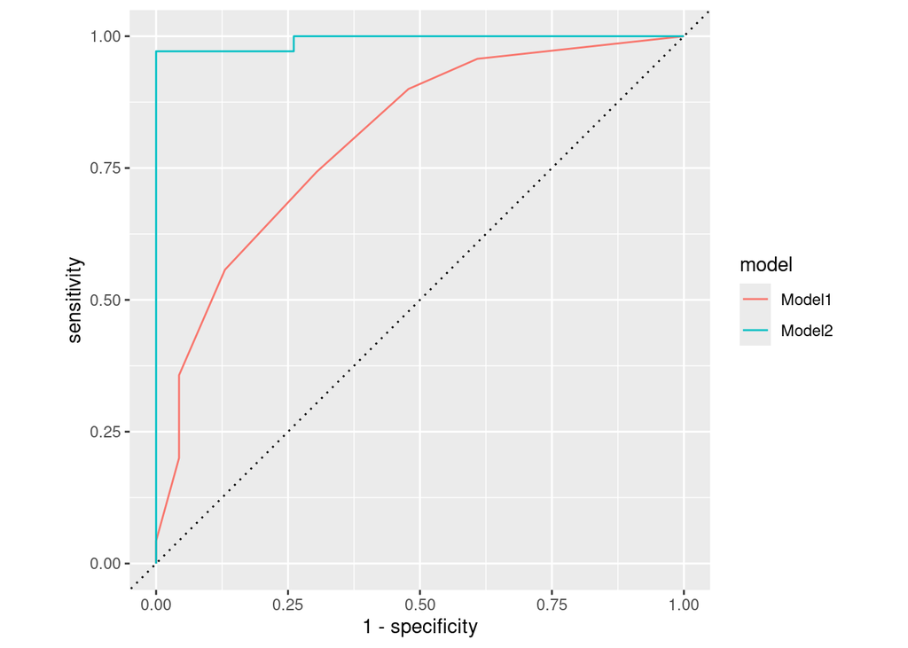

Comparing the Accuracy and Precision of both Models

### Diagnosing

```
## # A tibble: 1 × 2
##   .pred_appendicitis `.pred_no appendicitis`
##                <dbl>                   <dbl>
## 1               1.00                0.000358
```